# Barbell Lifts

Johanna Appel

7/7/2020

*This document is authored by Johanna Appel for the Practical Machine Learning Coursera Course. Do not plagiarize! If you see this document used as a submission by someone other than the author, please report!*

### Overview

In this document, we analyze and predict barbell lift exercise correctness based on data collected from different wearable sensor devices.

### Exploratory Analysis

```r
training = read.csv('./data/pml-training.csv', na.strings=c("","NA"))
testing = read.csv('./data/pml-testing.csv', na.strings=c("","NA"))
```

A preliminary look at the data reveals that it contains time series(es) and according measurement variables.

Since there are some many measurement variables, it is hard to do any meaningful analysis manually.

What we note, however, is that for a lot of observations the variables seem to be empty or NULL.

Additionally, the task is to predict the ‘classe’ variable for the test set, which only contains 20 observations - a lot of which are slices from different time series. That means we cannot make use of the structure of the time series to predict the ‘classe’, and need to only make use of the measurements.

### Data Transformation

We’ll start by creating a data set that contains only measurements and no time series. We’ll also impute any ‘NA’ value with 0 as a default measurement.

```r
format_df <- function(data) {
  # Remove the time series data
  df <- data[,-(1:7)]
  # Remove columns that contain no data
  df <- df %>% select(
    -kurtosis_yaw_belt, -skewness_yaw_belt, -amplitude_yaw_belt,
    -kurtosis_yaw_dumbbell, -skewness_yaw_dumbbell, -amplitude_yaw_dumbbell)
  # Make sure everything is numeric
  df <- df %>% mutate(across(everything(), as.numeric))
  # Replace empty measurement values with 0 by default
  df[is.na(df)] <- 0
  return(df)
}

# `testing` doesnt have a `classe` column, so to treat them similarly, we have to:
form_train <- format_df(training %>% select(-classe))
form_train$classe <- training$classe
# So that we can simply do:
form_test <- format_df(testing)
```

With this, we can preprocess the data automatically for prediction and use it to train our ML model:

### Training

```r
prep <- preProcess(form_train)
prep_train <- predict(prep, form_train)
prep_test <- predict(prep, form_test)
```

Since we have lots of different variables of which we don’t know the relevance, and we have to predict a categorical variable we’ll try out random forests and see how well they perform on the test set (by doing the Coursera Quiz).

```r
library(doParallel)
cl <- makePSOCKcluster(4)
registerDoParallel(cl)

smp <- runif(10000, min=1, max=length(prep_train$classe))
tn <- train(classe ~ ., data=prep_train[smp,], method="rf")

stopCluster(cl)

tn
```

```
## Random Forest
##
## 10000 samples
##   146 predictor
##     5 classes: 'A', 'B', 'C', 'D', 'E'
##
## No pre-processing
## Resampling: Bootstrapped (25 reps)
## Summary of sample sizes: 10000, 10000, 10000, 10000, 10000, 10000, ...
## Resampling results across tuning parameters:
##
##   mtry  Accuracy   Kappa
##     2   0.8074764  0.7529380
##    74   0.9864687  0.9828911
##   146   0.9786349  0.9729882
##
## Accuracy was used to select the optimal model using the largest value.
## The final value used for the model was mtry = 74.
```

#### Cross Validation

Since we are using a random forest model, employing a cross validation mechanism to split the training data set into chunks is not necessary. The random forest algorithm already uses a sub-sampling approach for observations (boosting) and variables for building the prediction model.

#### Out of Sample/Bag Error

Random forests calculating their out of sample error performance based on the samples not used for boosting (hence called out of bag error rate). For the trained model, this is quite low (< 1%):

```r
print(paste("Out of bag error: ", tail(tn$finalModel$err.rate[,1], n=1)))
```

```
## [1] "Out of bag error:  0.0074"
```

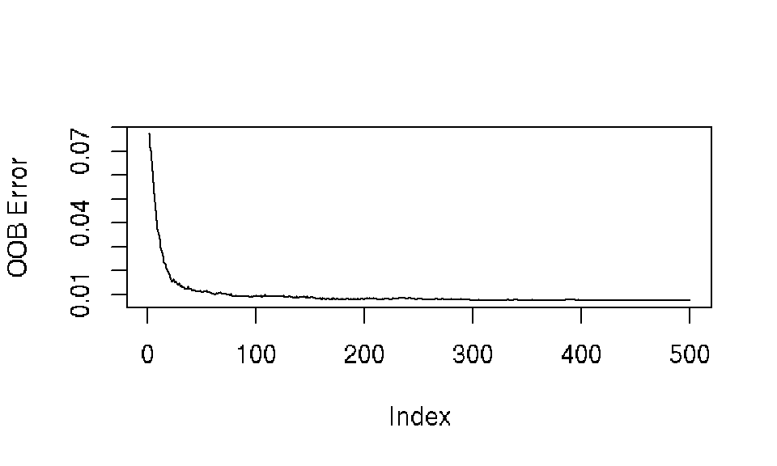

```r
plot(tn$finalModel$err.rate[,1], type = "l", ylab="OOB Error")
```

### Prediction

We simply run the prediction on our prepared test data set:

```r
predict(tn, prep_test)
```

```
##  [1] B A B A A E D B A A B C B A E E A B B B
## Levels: A B C D E
```

… which results in a full score on the quiz.